# 研究設計（續）：抽樣、實驗與推論範圍

IMS 2e · Study design · 以台北市長選舉民調為例  
回到 Week 03 Index

HT3001B 生物統計學與 R  
講師：張智宏

2026/09/24

## 從誰的資料，回答誰的問題？

2026 年 9 月中，一項民調訪問了 1,076 位設籍台北市、年滿 20 歲的民眾：41.7% 支持蔣萬安、40.5% 支持沈伯洋。

| 上週的名詞 | 在這個例子裡是什麼？ |
| --- | --- |
| 母群體（population） | 設籍台北市、年滿 20 歲的全體民眾 |
| 樣本（sample） | 成功完訪的 1,076 人 |
| 母群體參數（population parameter） | 全體民眾中支持某位候選人的比例；沒有人知道 |
| 樣本統計量（sample statistic） | 樣本算出的 41.7%、40.5% |

41.7% 是樣本的統計量，不是母群體的參數。要從 1,076 人談回兩百多萬人，先問：這些人是怎麼被選進來的？

IMS §2.1.2–2.1.4 · 信民協會／戴立安民調（2026-09-16–18），依 2026-09-22 報導轉述，來源見 assets 來源紀錄

## 同一個問題，三種選人方式

2026 年 9 月，「台北市長會投誰？」至少有三種不同的問法。

| 方式 | 誰被問到？ | 人數 | 結果（蔣：沈） |
| --- | --- | --- | --- |
| 電話訪問 | 隨機撥號抽到、願意回答的台北市民 | 1,076 | 41.7%：40.5% |
| 街頭訪問 | 某天在中山區某處願意停下來的路人 | 74 | 43 票：31 票 |
| 網路投票 | 自己上網站登入投票的人，不限台北市 | 約 19,000 | 16.4%：82.4% |

人數最多的一種，最不能代表台北市民：參加者是自己選擇進來的。便利樣本（convenience sample）與自我選擇樣本（self-selected sample）算不出抽樣誤差，人數再多也補不回來。

電話訪問：信民協會／戴立安（9/16–18）；街頭訪問：YouTube 頻道（9/20）；網路投票：壹蘋新聞網（9/1 起）。均依報導轉述

## 隨機抽樣（random sampling）：從全體到樣本

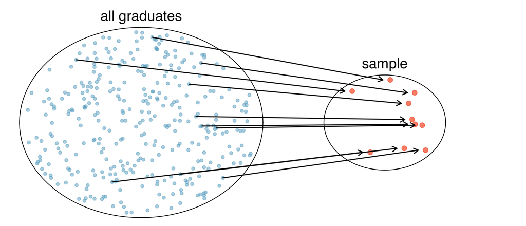

箭頭表示從母群體選出哪些人，不是把人分到不同處置組。電話民調的箭頭：從兩百多萬名市民，經由隨機撥號，到 1,076 位受訪者。

2.1.4 Sampling from a population · IMS Figure 2.1

## 人為挑選如何改變樣本？

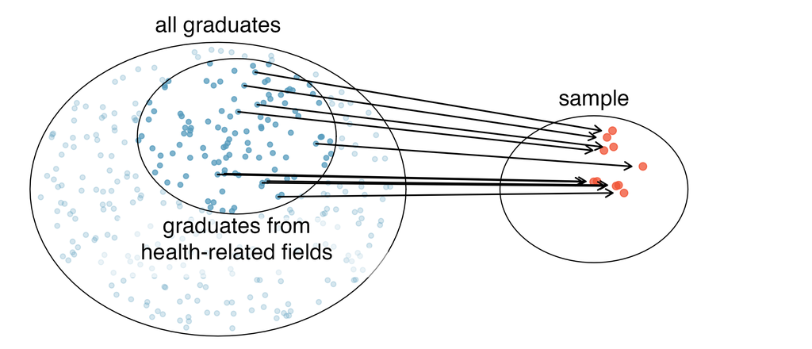

樣本偏差（sample bias）可能來自挑選程序。街頭訪問在某個地點、某個時段、只問願意停下來的人：哪些市民在這 74 人裡幾乎不會出現？

2.1.4 Sampling from a population · IMS Figure 2.2 · 街頭訪問依報導轉述

## 被抽到，不等於實際回應

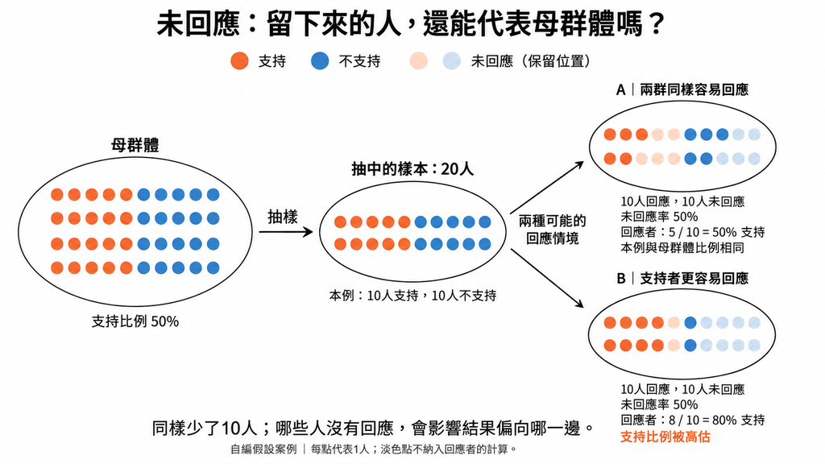

未回應（non-response）的影響，不只取決於少了多少人，也取決於哪些人沒有回應。

2.1.4 Sampling from a population · 自編假設案例與 AI 生成示意圖（非課本原圖）

## 練習：接觸 1,024 人，123 人拒訪

**5 月另一項民調：接觸 1,024 位 20 歲以上台北市民，123 位拒訪，有效樣本 901 人。**

拒訪率（refusal rate）是多少？結果就偏了這麼多嗎？

拒訪率＝123／1,024＝**12.0%**。

偏差有多大，還取決於拒訪者與受訪者在支持對象上的差異；這件事資料裡沒有。9 月民調另有約 17.8% 的受訪者未表態（undecided），是單一題目層次的未回應，同樣不能直接當成某一方的支持者。

2.1.4 Sampling from a population · TVBS 民調（2026-05-21–26）、信民協會／戴立安民調，依報導轉述

## 簡單隨機與分層抽樣

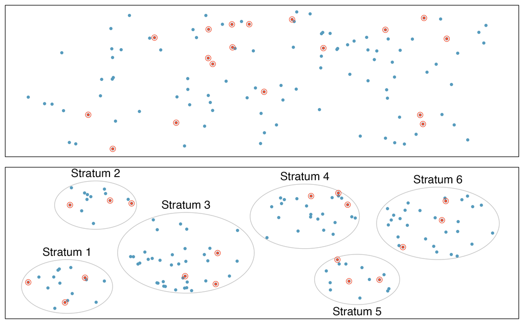

**上圖：簡單隨機抽樣**（simple random sampling）；**下圖：分層抽樣**（stratified sampling），每一層都抽一些。台北市民調常以 12 個行政區為層，每一區都抽到人。

簡單隨機樣本（simple random sample） 層（strata；單數 stratum）

2.1.5 Four sampling methods · IMS Figure 2.4

## 群聚與多階段抽樣

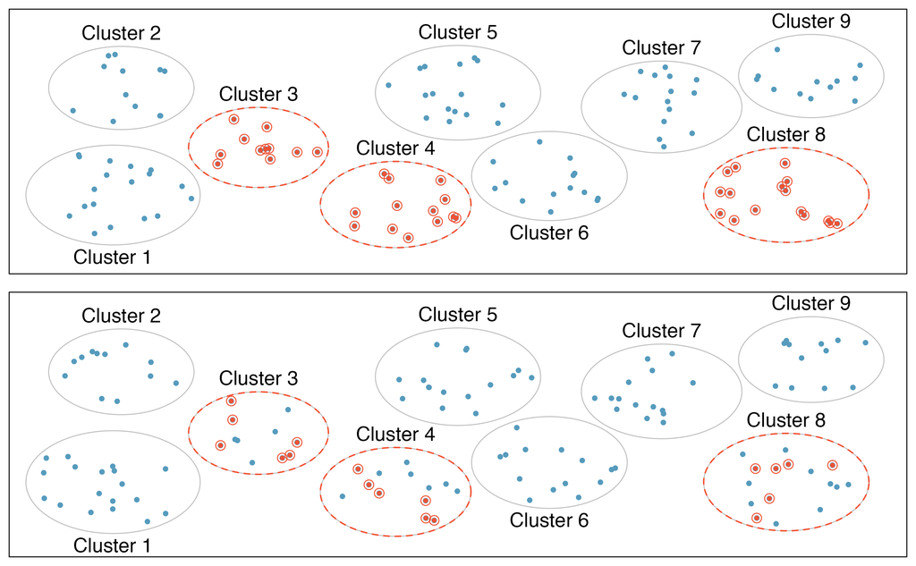

**上圖：群聚抽樣（cluster sampling）**，選一些群，群內全取；**下圖：多階段抽樣（multistage sampling）**，選一些群，群內再抽。若民調改成隨機抽幾個里、里內逐戶訪問，就是這兩種。

群聚（cluster） 群聚抽樣（cluster sampling） 多階段樣本（multistage sample）

2.1.5 Four sampling methods · IMS Figure 2.5

## 四種抽樣方法的程序比較

| 方法 | 從哪裡抽？ | 群內如何取人？ |
| --- | --- | --- |
| 簡單隨機 | 全市 20 歲以上市民名冊 | 直接抽人 |
| 分層 | 12 個行政區每一區都納入 | 每區內依人口比例抽人 |
| 群聚 | 隨機抽幾個里 | 所選里全體納入 |
| 多階段 | 隨機抽幾個里 | 所選里內再抽一些人 |

先問：每個群體都抽人，還是只選部分群體？選中的群體是全取，還是再抽一些人？台北市民調的常見做法是第二列。

2.1.5 Four sampling methods · 台北市民調示例

## 電話民調的抽樣底冊：市話與手機

| 步驟 | 這項民調怎麼做 | 對應的概念 |
| --- | --- | --- |
| 分層 | 報導寫「分層隨機抽樣」；台北市民調通常依 12 個行政區分層 | 分層抽樣 |
| 抽號碼 | 從住宅電話與行動電話兩份號碼庫隨機撥號 | 雙底冊（dual-frame）：住宅電話 752 人、行動電話 324 人 |
| 完訪 | 接通且願意回答，共 1,076 人 | 未回應在這一步發生 |

如果只打住宅電話，會漏掉誰？報導引述的涵蓋率：住宅電話 82.63%、行動電話 99.30%。

抽樣底冊（sampling frame）決定誰有機會被抽到；沒有住宅電話的人，在市話底冊裡被抽到的機會是零。8 月另一項民調只用市話，比較兩者時要先想到這點。

信民協會／戴立安民調（雙底冊）、TPOC 民調（2026-08-05–07，市話）；依報導轉述

## 隨機抽樣與隨機分派

### 隨機抽樣

random sampling

決定**誰進研究**。

連結樣本與目標母群體。

### 隨機分派（random assignment）

決定**接受哪種處置**。

提供因果比較的設計基礎。

民調只有抽樣，沒有分派：沒有人被隨機分到某個年齡、政黨或行政區。自願參加研究後再隨機分組，也不等於從母群體隨機抽樣。

2.1 Sampling principles and strategies · 2.2 Experiments

## 混淆（confounding）：還有什麼能解釋差異？

5 月一項民調的差距是 28 個百分點，9 月另一項只剩 1.2。

但兩項民調不只時間不同：

| 一起改變的因素 | 可能造成的差異 |
| --- | --- |
| 抽樣底冊：只打市話，或市話加手機 | 抽到的年齡組成不同 |
| 題目措辭與未表態的處理 | 兩位候選人的比例分母不同 |
| 執行機構與加權方式 | 各機構結果的系統性差異 |

差距一起隨時間變小，可能是支持度變了，也可能是方法變了；兩者綁在一起時，資料分不出哪一個是原因。

混淆變項（confounding variable）

2.2.1 Principles of experimental design · TVBS（5 月）、信民協會／戴立安（9 月）民調數字依報導轉述

## 實驗原則：控制與隨機化

| 原則 | 研究者做什麼？ |
| --- | --- |
| 控制（control／controlling） | 盡量固定量測流程、其他照護等條件 |
| 隨機化（randomization） | 用隨機程序分派處置，減少處置前因素與組別的系統性連結 |

隨機分派不保證單次分組就平衡；在反覆分派下，處置前的特徵平均而言不偏向某一組。民調沒有處置可分派，所以上一頁的混淆只能靠比較設計來拆解。

2.2.1 Principles of experimental design

## 實驗原則：區集（blocking）

先依處置前的風險分組，再在**每個區集內**隨機分派。

| 處置前風險 | 區集內隨機分派 |
| --- | --- |
| 低風險區集 | 部分接受處置，部分進入對照組 |
| 高風險區集 | 部分接受處置，部分進入對照組 |

分層抽樣決定誰進研究（民調依行政區分層）；區集分派決定研究中的人接受哪種處置。

區集 區集單位（block）

2.2.1 Principles of experimental design

## 區集分派：從風險分組到處置比較

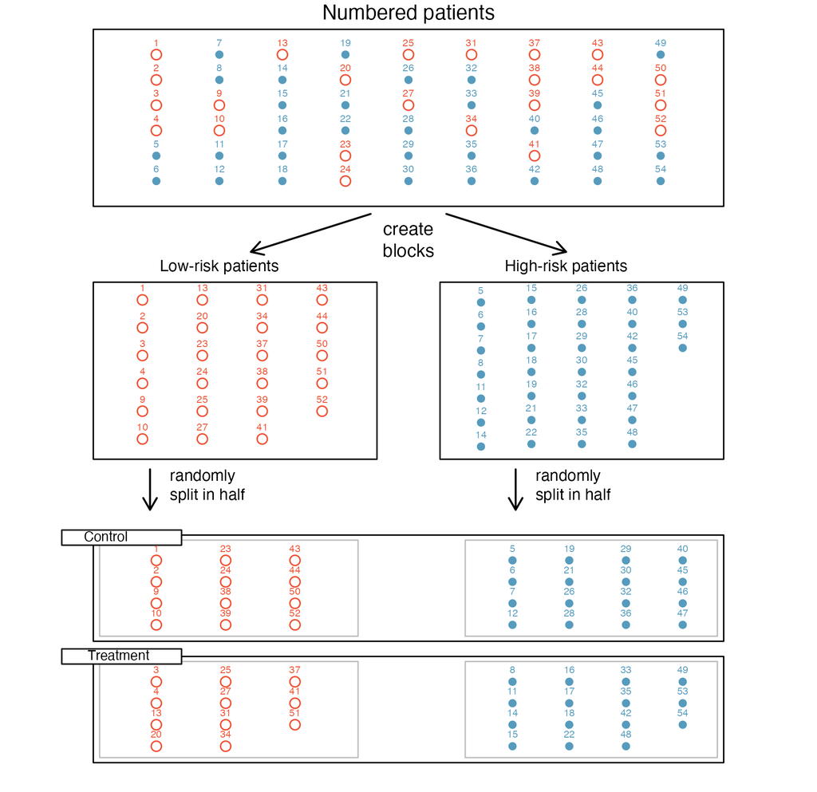

1. 先辨認處置前風險。

2. 分成低風險與高風險區集。

3. 在每個區集內隨機分派。

4. 處置組與對照組皆包含兩種風險。

2.2.1 Principles of experimental design · IMS Figure 2.6

## 安慰劑與盲法

| 設計 | 如何安排？ |
| --- | --- |
| 安慰劑（placebo） | 模擬處置經驗，協助處理期待影響 |
| 盲法（blind） | 參與者不知道自己的組別（依本節定義） |
| 雙盲（double-blind） | 相關照護／研究人員也不知道組別 |

判讀盲法時，先問：誰不知道組別？誰仍知道？

安慰劑效應（placebo effect） 處置組 對照組

2.2.2 Reducing bias in human experiments

## 實驗原則：重複（replication）與偽重複（pseudoreplication）

原書例子：**50 人，每人測量 10 次血壓。**

資料有 500 筆，是否等於 500 個獨立受試者？

有 500 筆測量，但只有 50 位受試者；同一人的多次測量可能相依。民調的 1,076 筆各來自不同受訪者，才能當 1,076 個觀察值。

重複 實驗單位（experimental unit） 偽重複

2.2.1 Principles of experimental design

## 觀察值之間的連結

| 資料關係 | 連結從哪裡來？ | 資料中要記錄什麼？ |
| --- | --- | --- |
| 配對資料（paired data） | 同一人前後測，或依規則匹配 | 個人／配對 ID |
| 重複測量（repeated measures） | 同一人多次訪視 | 個人 ID、時間 |
| 群聚資料（clustered data） | 同家庭、同班、同診所 | 群聚 ID |

不同 ID 不足以保證獨立；同一人兩次觀察也不會變成兩個人。同一支住宅電話若接到兩位家人，也是一種群聚。

獨立觀察（independent observations）

Week 03 · 觀察單位與相依性

## 民調資料的一列是什麼？

| respondent_id | district | frame | age_group | support |
| --- | --- | --- | --- | --- |
| R0001 | 大安 | 手機 | 30–39 | 沈伯洋 |
| R0002 | 士林 | 市話 | 60+ | 蔣萬安 |
| R0003 | 大安 | 市話 | 50–59 | 未表態 |
| R0004 | 南港 | 手機 | 20–29 | 沈伯洋 |

一列是一位受訪者；1,076 列、12 個行政區、2 種底冊。行政區是分層的層，也是之後分組計數的依據。

這四列是依報導的變項自編的示意，不是原始資料。未表態要有自己的編碼，不能留空。

Week 03 · 依民調變項自編的資料結構示例

## 觀察研究（observational study）的時間方向

| 設計 | 資料蒐集方向 |
| --- | --- |
| 前瞻性研究（prospective study） | 界定研究對象後，隨事件發生持續蒐集 |
| 回溯性研究（retrospective study） | 事件已發生後，回查既往資料 |

同一研究可以先查病歷，再追蹤後續結果。民調在同一個時間點問一次，是橫斷式（cross-sectional）的觀察研究。

時間方向與處置分派方式，需要分別判斷。

觀察研究 觀察資料（observational data） 世代（cohort）

2.3 Observational studies

## 混淆的圖像：日曬、防曬與皮膚癌

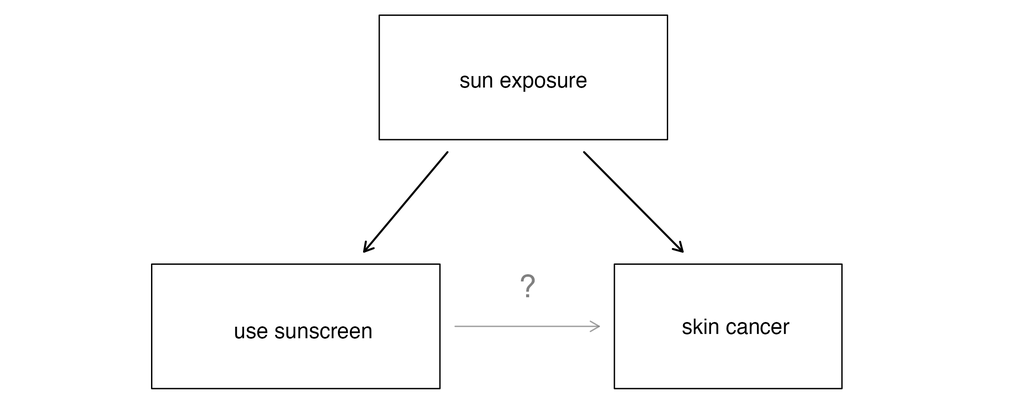

日曬可能同時影響兩者；觀察到的關聯不足以單獨判定直接因果。民調裡「年齡與支持對象有關」也是同一類關聯。

2.3 Observational studies · IMS Figure 2.7 · 原書假想關聯

## 判讀結論：先查設計，再查執行

| 先問什麼？ | 影響哪一種判斷？ |
| --- | --- |
| 研究對象怎麼選進來？ | 結果能推廣到誰 |
| 處置怎麼分給研究對象？ | 組間差異能否支持因果比較 |
| 哪些人未回應、退出？測量與處置如何執行？ | 原本的設計基礎是否受到影響 |

抽樣與分派回答不同問題；還要確認研究是否依設計執行，才能界定結論範圍。

IMS §2.1–2.3、§2.4.1 Summary · 本課程整理

## 能推廣到誰？能判斷因果嗎？

[figure not shown]

看列：樣本如何取得、能推廣到誰？看欄：處置如何分派、能否支持因果推論（causal inference）？兩者不能互相替代。

2.4.1 Summary · IMS Figure 2.8 · 中文翻譯重製

## 民調的結論能說到哪裡？

同一份民調，報導寫出三種說法：

1. 「50 歲以上較支持蔣萬安，20–49 歲較支持沈伯洋。」
2. 「差距只有 1.2 個百分點，選情翻轉。」
3. 「民眾黨支持者 88.5% 支持蔣萬安。」

看列：隨機抽樣，可推廣到「9 月中能被電話接觸、願意回答的台北市民」，不是 11 月的投票者。看欄：沒有隨機分派，年齡、政黨與支持對象的關係是關聯，不是年齡造成支持。差距 1.2 小於抽樣誤差 ±3.0，「翻轉」超出這份資料能支持的範圍。

2.4.1 Summary 概念應用 · 信民協會／戴立安民調（2026-09-16–18），依報導轉述

## 練習：隨機發生在哪一步？

某門診招募自願參與者，再用抽籤決定接受新照護方案或既有照護。

1. 是否隨機抽樣？是否隨機分派？
2. 這種分組方式能支持因果比較嗎？結果能直接推廣到其他人嗎？

自願招募；隨機分派。參與者內的因果比較有設計基礎，外推到其他人仍需依據。和民調正好相反：民調有隨機抽樣、沒有分派。

2.5 Exercises · 自編虛構案例

## 讀圖練習：網路使用與預期壽命

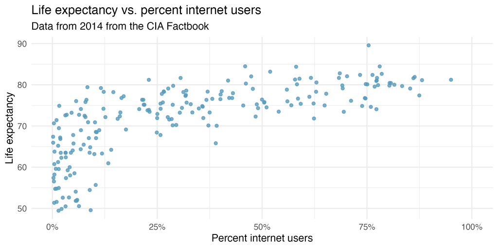

這是觀察研究。除了網路使用比例，還有哪些因素可能同時與兩個變項有關？

2.5 Exercises · 題 11 Internet use and life expectancy

## 讀圖練習：學歷比例與人均收入

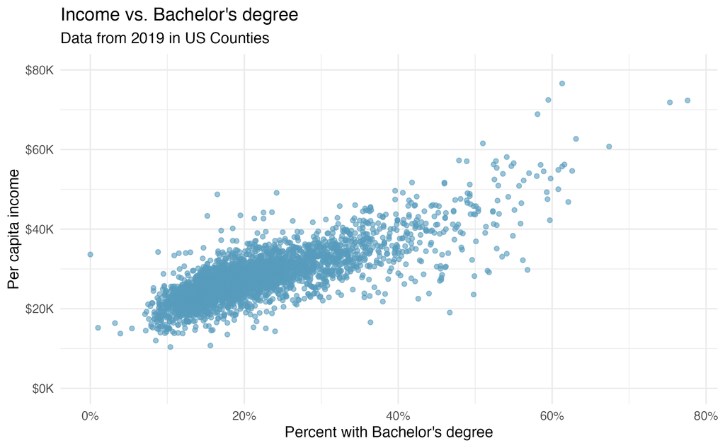

每個點是一個郡。這個關聯能直接解釋為個人取得學位造成收入增加嗎？

2.5 Exercises · 題 28 Income and education in US counties

## 這些名詞有什麼不同？

| 容易混淆的名詞 | 差別在哪裡？ |
| --- | --- |
| population／sample | 想描述的全體與實際觀察的部分 |
| parameter／statistic | 想知道的母群體特徵與樣本算出的結果 |
| sampling frame／sample | 有機會被抽到的名單，與實際抽到的人 |
| stratified／cluster sampling | 每層都抽與選部分群 |
| control／control group | 控制條件與比較基準 |
| replication／pseudoreplication | 增加獨立實驗單位，或把相依測量誤當獨立資料 |

2.4.2 Terms · Table 2.1 · 底冊一列為本課程補充

## 資料手冊需要記錄什麼？

- **識別：**受訪者 ID；分層用的行政區。
- **時間：**訪問日期（9/16–18），與投票日相距兩個多月。
- **變項：**支持對象的類別編碼，未表態要有自己的代碼；年齡組、政黨認同的定義。
- **來源：**市話與手機兩份底冊、撥號程序、拒訪與未完訪人數、加權方式。

除了欄位名稱和數值，也要記錄資料是怎麼蒐集、怎麼測量的。先確認每列代表什麼，才能決定圖表要數什麼、比較什麼。

Week 03 · 以民調為例的變項定義與資料來源

## Part 1｜Slido 作答入口

[figure not shown]

掃描 QR code 進入 Slido，等待 **Part 1 Quiz** 開放。

無法掃描時，開啟 [Slido 作答入口](https://app.sli.do/event/kZvJoQiKAfkNbFnuJrvTxP)，或到 sli.do 輸入代碼 **8092699**。